# Task 5

Cole Hon

9/12/2022

```r
library(tidyverse)
```

```r
library(downloader)
library(ggplot2)
library(knitr)
```

```r
SoloData <- read_csv("solo-artist-followers.csv")
SoloData
```

```
## # A tibble: 139 × 5
##    name              band              followers band_followers follower_differ…
##    <chr>             <chr>             <chr>     <chr>          <chr>
##  1 Daron Jones       112               1.28k     783k           −782k
##  2 Slim              112               2.14k     783k           −781k
##  3 Q Parker          112               3.51k     783k           −780k
##  4 JC Chasez         *NSYNC            30.8k     1.44M          −1.41M
##  5 Joey Fatone       *NSYNC            1.13k     1.44M          −1.44M
##  6 Justin Timberlake *NSYNC            10.3M     1.44M          8.90M
##  7 Ashton Irwin      5 Seconds of Sum… 130k      7.14M          −7.01M
##  8 Abz Love          5ive              223       19.0k          −18.7k
##  9 Jeff Timmons      98º               111       302k           −302k
## 10 Nick Lachey       98º               142k      302k           −160k
## # … with 129 more rows
```

```r
str(SoloData)
```

```
## spec_tbl_df [139 × 5] (S3: spec_tbl_df/tbl_df/tbl/data.frame)
##  $ name               : chr [1:139] "Daron Jones" "Slim" "Q Parker" "JC Chasez" ...
##  $ band               : chr [1:139] "112" "112" "112" "*NSYNC" ...
##  $ followers          : chr [1:139] "1.28k" "2.14k" "3.51k" "30.8k" ...
##  $ band_followers     : chr [1:139] "783k" "783k" "783k" "1.44M" ...
##  $ follower_difference: chr [1:139] "−782k" "−781k" "−780k" "−1.41M" ...
##  - attr(*, "spec")=
##   .. cols(
##   ..   name = col_character(),
##   ..   band = col_character(),
##   ..   followers = col_character(),
##   ..   band_followers = col_character(),
##   ..   follower_difference = col_character()
##   .. )
##  - attr(*, "problems")=<externalptr>
```

Data Sucessfully imported. All data consists of characters.

```r
BillBoardData <- read_csv("billboard-hits.csv")
BillBoardData
```

```
## # A tibble: 456 × 5
##    name   band  title                     peak_date  peak_rank
##    <chr>  <chr> <chr>                     <date>         <dbl>
##  1 *NSYNC <NA>  It's Gonna Be Me          2000-07-28         1
##  2 *NSYNC <NA>  Music Of My Heart         1999-10-15         2
##  3 *NSYNC <NA>  Bye Bye Bye               2000-04-14         4
##  4 *NSYNC <NA>  This I Promise You        2000-12-01         5
##  5 *NSYNC <NA>  Girlfriend                2002-04-05         5
##  6 *NSYNC <NA>  A Little More Time On You 1999-02-26         8
##  7 *NSYNC <NA>  Gone                      2001-11-23        11
##  8 *NSYNC <NA>  I Want You Back           1998-05-01        13
##  9 *NSYNC <NA>  Pop                       2001-06-15        19
## 10 *NSYNC <NA>  Tearin' Up My Heart       1998-12-04        59
## # … with 446 more rows
```

```r
str(BillBoardData)
```

```
## spec_tbl_df [456 × 5] (S3: spec_tbl_df/tbl_df/tbl/data.frame)
##  $ name     : chr [1:456] "*NSYNC" "*NSYNC" "*NSYNC" "*NSYNC" ...
##  $ band     : chr [1:456] NA NA NA NA ...
##  $ title    : chr [1:456] "It's Gonna Be Me" "Music Of My Heart" "Bye Bye Bye" "This I Promise You" ...
##  $ peak_date: Date[1:456], format: "2000-07-28" "1999-10-15" ...
##  $ peak_rank: num [1:456] 1 2 4 5 5 8 11 13 19 59 ...
##  - attr(*, "spec")=
##   .. cols(
##   ..   name = col_character(),
##   ..   band = col_character(),
##   ..   title = col_character(),
##   ..   peak_date = col_date(format = ""),
##   ..   peak_rank = col_double()
##   .. )
##  - attr(*, "problems")=<externalptr>
```

```r
head(BillBoardData)
```

```
## # A tibble: 6 × 5
##   name   band  title                     peak_date  peak_rank
##   <chr>  <chr> <chr>                     <date>         <dbl>
## 1 *NSYNC <NA>  It's Gonna Be Me          2000-07-28         1
## 2 *NSYNC <NA>  Music Of My Heart         1999-10-15         2
## 3 *NSYNC <NA>  Bye Bye Bye               2000-04-14         4
## 4 *NSYNC <NA>  This I Promise You        2000-12-01         5
## 5 *NSYNC <NA>  Girlfriend                2002-04-05         5
## 6 *NSYNC <NA>  A Little More Time On You 1999-02-26         8
```

Data successfully imported. Data types include characters & dates.

```r
six100 <- BillBoardData %>%
  group_by(name) %>%
  filter(n() > 6, band != "")
six100
```

```
## # A tibble: 144 × 5
## # Groups:   name [10]
##    name              band   title                           peak_date  peak_rank
##    <chr>             <chr>  <chr>                           <date>         <dbl>
##  1 Justin Timberlake *NSYNC SexyBack                        2006-09-08         1
##  2 Justin Timberlake *NSYNC My Love                         2006-11-10         1
##  3 Justin Timberlake *NSYNC What Goes Around...Comes Around 2007-03-02         1
##  4 Justin Timberlake *NSYNC Can't Stop The Feeling!         2016-05-27         1
##  5 Justin Timberlake *NSYNC Mirrors                         2013-06-14         2
##  6 Justin Timberlake *NSYNC Cry Me A River                  2003-01-31         3
##  7 Justin Timberlake *NSYNC Suit & Tie                      2013-04-05         3
##  8 Justin Timberlake *NSYNC Rock Your Body                  2003-05-09         5
##  9 Justin Timberlake *NSYNC Summer Love                     2007-06-08         6
## 10 Justin Timberlake *NSYNC Not A Bad Thing                 2014-05-02         8
## # … with 134 more rows
```

Finding the bands who have been in top 100 at least 6 times

```r
sixtopbands <- BillBoardData %>%
  group_by(band) %>%
  filter(name %in% six100$band)
head(sixtopbands)
```

```
## # A tibble: 6 × 5
## # Groups:   band [1]
##   name   band  title                     peak_date  peak_rank
##   <chr>  <chr> <chr>                     <date>         <dbl>
## 1 *NSYNC <NA>  It's Gonna Be Me          2000-07-28         1
## 2 *NSYNC <NA>  Music Of My Heart         1999-10-15         2
## 3 *NSYNC <NA>  Bye Bye Bye               2000-04-14         4
## 4 *NSYNC <NA>  This I Promise You        2000-12-01         5
## 5 *NSYNC <NA>  Girlfriend                2002-04-05         5
## 6 *NSYNC <NA>  A Little More Time On You 1999-02-26         8
```

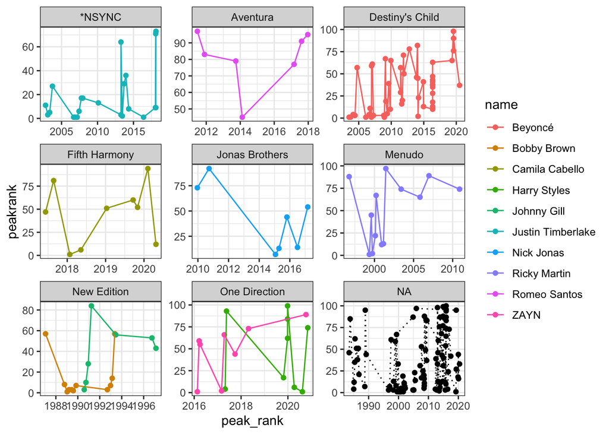

```r
plots <- ggplot(data = six100, aes(x=peak_date, y=peak_rank, color=name, group=name)) +
  geom_point() +
  geom_line() +
  geom_point(data = sixtopbands, color = "black") +
  geom_line(data = sixtopbands, color = "black", linetype = "dotted") +
  facet_wrap(~ band, scales = "free") +
  xlab("peak_rank") + ylab("peakrank") +
  theme_bw()
plots
```

Observavtions that can be made: - Beyonce has consitently been in the top 100 for the longest period of time, with the most appearances out of everyone else

```r
KC2021Crime <- read_csv("KCPD_Crime_Data_2021.csv")
KC2021Crime
```

```
## # A tibble: 92,127 × 24
##    Report_No  Reported_Date Reported_Time From_Date  From_Time To_Date   To_Time
##    <chr>      <chr>         <time>        <chr>      <time>    <chr>     <time>
##  1 KC21055624 08/21/2021    19:45         08/21/2021 19:45     <NA>         NA
##  2 KC21012401 02/24/2021    11:35         02/24/2021 11:35     <NA>         NA
##  3 KC21017210 03/17/2021    15:46         03/17/2021 15:35     <NA>         NA
##  4 KC21005420 01/25/2021    11:18         01/25/2021 11:00     <NA>         NA
##  5 KC21010791 02/17/2021    11:41         02/11/2021 20:30     02/11/20… 20:45
##  6 KC21012025 02/22/2021    17:55         02/22/2021 17:55     <NA>         NA
##  7 KC21001020 01/05/2021    19:45         01/05/2021 19:40     <NA>         NA
##  8 KC21010782 02/17/2021    10:07         02/17/2021 09:55     <NA>         NA
##  9 KC21003742 01/17/2021    22:08         01/17/2021 21:30     <NA>         NA
## 10 KC21004843 01/22/2021    15:53         01/22/2021 15:50     <NA>         NA
## # … with 92,117 more rows, and 17 more variables: Offense <chr>, IBRS <chr>,
## #   Description <chr>, Beat <dbl>, Address <chr>, City <chr>, `Zip Code` <dbl>,
## #   Rep_Dist <chr>, Area <chr>, DVFlag <lgl>, Involvement <chr>, Race <chr>,
## #   Sex <chr>, Age <dbl>, `Firearm Used Flag` <lgl>, Location <chr>,
## #   Age_Range <chr>
```

```r
str(KC2021Crime)
```

```
## spec_tbl_df [92,127 × 24] (S3: spec_tbl_df/tbl_df/tbl/data.frame)
##  $ Report_No        : chr [1:92127] "KC21055624" "KC21012401" "KC21017210" "KC21005420" ...
##  $ Reported_Date    : chr [1:92127] "08/21/2021" "02/24/2021" "03/17/2021" "01/25/2021" ...
##  $ Reported_Time    : 'hms' num [1:92127] 19:45:00 11:35:00 15:46:00 11:18:00 ...
##   ..- attr(*, "units")= chr "secs"
##  $ From_Date        : chr [1:92127] "08/21/2021" "02/24/2021" "03/17/2021" "01/25/2021" ...
##  $ From_Time        : 'hms' num [1:92127] 19:45:00 11:35:00 15:35:00 11:00:00 ...
##   ..- attr(*, "units")= chr "secs"
##  $ To_Date          : chr [1:92127] NA NA NA NA ...
##  $ To_Time          : 'hms' num [1:92127] NA NA NA NA ...
##   ..- attr(*, "units")= chr "secs"
##  $ Offense          : chr [1:92127] "Murder" "Stealing from Building/Residence" "Assault (Aggravated)" "Recovered Stolen Auto" ...
##  $ IBRS             : chr [1:92127] "09A" "23D" "13A" NA ...
##  $ Description      : chr [1:92127] "Murder" "Theft From Building" "Aggravated Assault" NA ...
##  $ Beat             : num [1:92127] 332 234 631 113 211 222 534 533 541 641 ...
##  $ Address          : chr [1:92127] "3500  AGNES AVE" "8800  STATE LINE RD" "NE PARVIN RD and I 29 HWY" "1500  CENTRAL ST" ...
##  $ City             : chr [1:92127] "KANSAS CITY" "KANSAS CITY" "KANSAS CITY" "KANSAS CITY" ...
##  $ Zip Code         : num [1:92127] 64128 64114 64116 64105 64130 ...
##  $ Rep_Dist         : chr [1:92127] "PJ2878" "PJ6174" NA NA ...
##  $ Area             : chr [1:92127] "EPD" "MPD" "SCP" "CPD" ...
##  $ DVFlag           : logi [1:92127] FALSE FALSE FALSE FALSE FALSE FALSE ...
##  $ Involvement      : chr [1:92127] "VIC" "SUS" "ARR CHA" "SUS" ...
##  $ Race             : chr [1:92127] "B" "B" "B" "W" ...
##  $ Sex              : chr [1:92127] "M" "M" "M" "F" ...
##  $ Age              : num [1:92127] NA NA 33 20 NA 28 20 23 NA 46 ...
##  $ Firearm Used Flag: logi [1:92127] TRUE FALSE TRUE FALSE FALSE FALSE ...
##  $ Location         : chr [1:92127] NA NA NA NA ...
##  $ Age_Range        : chr [1:92127] NA NA "25-34" "18-24" ...
##  - attr(*, "spec")=
##   .. cols(
##   ..   Report_No = col_character(),
##   ..   Reported_Date = col_character(),
##   ..   Reported_Time = col_time(format = ""),
##   ..   From_Date = col_character(),
##   ..   From_Time = col_time(format = ""),
##   ..   To_Date = col_character(),
##   ..   To_Time = col_time(format = ""),
##   ..   Offense = col_character(),
##   ..   IBRS = col_character(),
##   ..   Description = col_character(),
##   ..   Beat = col_double(),
##   ..   Address = col_character(),
##   ..   City = col_character(),
##   ..   `Zip Code` = col_double(),
##   ..   Rep_Dist = col_character(),
##   ..   Area = col_character(),
##   ..   DVFlag = col_logical(),
##   ..   Involvement = col_character(),
##   ..   Race = col_character(),
##   ..   Sex = col_character(),
##   ..   Age = col_double(),
##   ..   `Firearm Used Flag` = col_logical(),
##   ..   Location = col_character(),
##   ..   Age_Range = col_character()
##   .. )
##  - attr(*, "problems")=<externalptr>
```

https://data.kcmo.org/Crime/KCPD-Crime-Data-2021/w795-ffu6 This data consists of Crimes reported by the KCPD in 2021. It read in correctly but jsut like any data set in the real workd, there are missing entries, resulting in “parsing issues” The data consists of time stmaps and characters.

```r
KCCovidDeath <- read_csv("COVID-19_Case___Death_Trends_by_Date.csv")
KCCovidDeath
```

```
## # A tibble: 908 × 5
##    Date                   `Total Cases` `New Cases` `Total Deaths` `New Deaths`
##    <chr>                          <dbl>       <dbl>          <dbl>        <dbl>
##  1 03/10/2020 12:00:00 AM             0           0              0            0
##  2 03/11/2020 12:00:00 AM             0           0              0            0
##  3 03/12/2020 12:00:00 AM             0           0              0            0
##  4 03/13/2020 12:00:00 AM             0           0              0            0
##  5 03/14/2020 12:00:00 AM             1           1              0            0
##  6 03/15/2020 12:00:00 AM             2           1              0            0
##  7 03/16/2020 12:00:00 AM             6           4              0            0
##  8 03/17/2020 12:00:00 AM             9           3              0            0
##  9 03/18/2020 12:00:00 AM            12           3              0            0
## 10 03/19/2020 12:00:00 AM            22          10              0            0
## # … with 898 more rows
```

```r
str(KCCovidDeath)
```

```
## spec_tbl_df [908 × 5] (S3: spec_tbl_df/tbl_df/tbl/data.frame)
##  $ Date        : chr [1:908] "03/10/2020 12:00:00 AM" "03/11/2020 12:00:00 AM" "03/12/2020 12:00:00 AM" "03/13/2020 12:00:00 AM" ...
##  $ Total Cases : num [1:908] 0 0 0 0 1 2 6 9 12 22 ...
##  $ New Cases   : num [1:908] 0 0 0 0 1 1 4 3 3 10 ...
##  $ Total Deaths: num [1:908] 0 0 0 0 0 0 0 0 0 0 ...
##  $ New Deaths  : num [1:908] 0 0 0 0 0 0 0 0 0 0 ...
##  - attr(*, "spec")=
##   .. cols(
##   ..   Date = col_character(),
##   ..   `Total Cases` = col_double(),
##   ..   `New Cases` = col_double(),
##   ..   `Total Deaths` = col_double(),
##   ..   `New Deaths` = col_double()
##   .. )
##  - attr(*, "problems")=<externalptr>
```

https://data.kcmo.org/Health/COVID-19-Case-Death-Trends-by-Date/nfta-sjx6 This data consists of Covid deaths in KC from march 2020 to september 2022. It includes dates, total cases, new cases, total deaths, new deaths.

```r
BadBuildings <- read_csv("Dangerous_Buildings_List.csv")
BadBuildings
```

```
## # A tibble: 442 × 10
##    `Case Number` Address        `ZIP Code` `Case Opened` `Status of Case`    PIN
##    <chr>         <chr>               <dbl> <chr>         <chr>             <dbl>
##  1 2021-00472    711 Monroe Ave      64124 10/07/2019    Pre-Bid Process…   9682
##  2 2021-00354    2304 Kensingt…      64127 08/22/2017    Repair Case w/E…  19318
##  3 2021-00423    3933 Vineyard…      64130 08/19/2020    Ongoing Case      32092
##  4 2021-00326    5549 Wabash A…      64130 04/09/2020    Pre-Bid Process… 147645
##  5 2022-00127    6908 Dr Marti…      64129 05/20/2022    Ongoing Case      54417
##  6 2021-00445    805 N Montgal…      64120 06/19/2019    Rehab By Owner …  38822
##  7 2021-00299    1815 Paseo          64108 04/04/2017    Rehab By Owner …  13253
##  8 2021-00430    4442 South Be…      64130 09/21/2016    Rehab By Owner …  34592
##  9 2021-00353    4205 E 24th St         NA 05/20/2021    Ongoing Case         NA
## 10 2021-00505    3226 E 6th St       64124 12/21/2021    Ongoing Case      10389
## # … with 432 more rows, and 4 more variables: `Council District` <dbl>,
## #   Latitude <dbl>, Longitude <dbl>, Location <chr>
```

```r
str(BadBuildings)
```

```
## spec_tbl_df [442 × 10] (S3: spec_tbl_df/tbl_df/tbl/data.frame)
##  $ Case Number     : chr [1:442] "2021-00472" "2021-00354" "2021-00423" "2021-00326" ...
##  $ Address         : chr [1:442] "711 Monroe Ave" "2304 Kensington Ave" "3933 Vineyard Rd." "5549 Wabash Ave" ...
##  $ ZIP Code        : num [1:442] 64124 64127 64130 64130 64129 ...
##  $ Case Opened     : chr [1:442] "10/07/2019" "08/22/2017" "08/19/2020" "04/09/2020" ...
##  $ Status of Case  : chr [1:442] "Pre-Bid Process Ongoing" "Repair Case w/Enforcement" "Ongoing Case" "Pre-Bid Process Ongoing" ...
##  $ PIN             : num [1:442] 9682 19318 32092 147645 54417 ...
##  $ Council District: num [1:442] 3 3 3 5 5 4 3 3 NA 3 ...
##  $ Latitude        : num [1:442] 39.1 39.1 39.1 39 39 ...
##  $ Longitude       : num [1:442] -94.5 -94.5 -94.5 -94.6 -94.5 ...
##  $ Location        : chr [1:442] "711 Monroe Ave\nKansas City, MO 64124\n(39.10364, -94.538633)" "2304 Kensington Ave\nKansas City, MO 64127\n(39.083427, -94.53196)" "3933 Vineyard Rd\nKansas City, MO 64130\n(39.05364, -94.525094)" "5549 Wabash Ave\nKansas City, MO 64130\n(39.024927, -94.556114)"…
##  - attr(*, "spec")=
##   .. cols(
##   ..   `Case Number` = col_character(),
##   ..   Address = col_character(),
##   ..   `ZIP Code` = col_double(),
##   ..   `Case Opened` = col_character(),
##   ..   `Status of Case` = col_character(),
##   ..   PIN = col_double(),
##   ..   `Council District` = col_double(),
##   ..   Latitude = col_double(),
##   ..   Longitude = col_double(),
##   ..   Location = col_character()
##   .. )
##  - attr(*, "problems")=<externalptr>
```

https://data.kcmo.org/Neighborhoods/Dangerous-Buildings-List/ax3m-jhxx This is a list of dangerous buildings in KC. A building is deemed dangerous if they do not meet building code standards.What is in this dataset is the adress, case number, coordinates, and case status.